# Flatening out the curve: model-driven estimates of COVID-19 disease progression in The Netherlands

Antonios Zagaris

3/29/2020

## Scope

On March 16, 2020, the Dutch premier announced that the country’s response to the COVID-19 pandemic will be to pursue *herd immunity*. In plain terms, this means that a substantial part of the population will need to become immune to the disease by contracting it and developing antibodies.[^1]

The official numbers show that active COVID-19 cases in NL increase by approximately $22\%$ daily or $300\%$ weekly, raising concerns about the Dutch public health system’s capacity to cope. The administration’s response to these concens has been to introduce *social distancing* measures, which are meant to slow down epidemic spread and prevent the health system from getting overwhelmed.

This approach raises a number of questions, the most pertinent of which are in my opinion:

- To what extent must epidemic spread be slowed down to achieve this?
- How long before the light at the end of the tunnel?

As a mathematical modeler, I attempted to quench my curiosity by sifting through data and setting up a rough predictive model — regrettably, without the benefit of consulting with expert former colleagues. My approach is necessarily limited in scope, as I am limited in time, but hopefully adds signal to the noise. The R code I wrote for this study can be found [here](https://github.com/azagaris/COVID-19); see also [this simulation tool](https://gabgoh.github.io/COVID/index.html) written by [Gabriel Goh](https://www.linkedin.com/in/gabriel-goh-8ab441b5/).

All in all, model projections play out *very badly* for the herd immunity scenario. There is, however, a significant shadow cast on these projections by the fact that we’re unaware of how many infections go unreported. Unless $98\%$ or more of the cases go unreported, though, hospital capacity is projected to be vastly inadequate to cope with this menace as it currently evolves.

[figure not shown]

*The principle behind flattening the epidemic curve ([source](https://www.health.harvard.edu/diseases-and-conditions/coronavirus-resource-center#COVID))*.

## Model

I model epidemic spread using the basic SIR model
$$\begin{align}
\frac{dI(t)}{dt} &= \beta I \frac{S}{N} - \gamma I , \nonumber
\\
\frac{dS(t)}{dt} &= -\beta I \frac{S}{N} , \nonumber
\\
\frac{dR(t)}{dt} &= \gamma I . \nonumber
\end{align}$$
The variable $I(t)$ counts infected inividuals in The Netherlands (NL) at time $t$, whereas $S(t)$ counts susceptibles and $R(t)$ the rest of the population. Clearly, these three variables sum up to the total population ($N \approx 17$ million) at all times. The parameters $\beta$ and $\gamma$ measure the rates of transmission and recovery, respectively, and will be estimated from data.

This model can be challenged at several obvious fronts, most importantly due to being simplistic to the point of offense. This choice was inevitable, however, both to expedite the study and because publicly available data for model calibration remain scarce.[^2] Another data-related challenge is that the actual number of infecteds is *absolutely certainly significantly higher* than [reported numbers](https://github.com/CSSEGISandData/COVID-19/blob/master/csse_covid_19_data/csse_covid_19_time_series/time_series_covid19_confirmed_global.csv).[^3] A guiding assumption in my work below is that the actual number of infections, $I(t)$, remains proportional to the reported figure $I_\mathrm{rep}(t)$:
$$\begin{equation}
\label{p.def}
\frac{I(t)}{I_\mathrm{rep}(t)} = p
\ \mbox{is a constant greater than one} .
\end{equation}$$
This means, in effect, that an infected person has a specific (if unknown) probablity to satisfy RIVM guidelines for testing *and* test positive *and* be officially reported. To proceed with the study, $p$ must be known or estimated; I revisit this issue below. For now, I merely note that the reported number of infections evolves in par with the true one,
$$\frac{dI_\mathrm{rep}(t)}{dt} = \beta I_\mathrm{rep} \frac{S}{N} - \gamma I_\mathrm{rep} .$$
This is significant below, as it allows model calibration on the basis of the reported (rather than the unknown actual) infection numbers.

## Parameter Estimates

**Estimating $\gamma$.** The rate of recovery $\gamma$ is estimated from
$$\gamma = \frac{1}{T_\mathrm{rec}},
\quad\mbox{where $T_\mathrm{rec}$ is the average recovery period.}$$
Recovery data from NL are not available: at the time of writing this (March 22), the [JHU dashboard](https://coronavirus.jhu.edu/map.html) has been reporting $2$ recoveries for the past several weeks, as well as $4,216$ cases and $180$ deaths. Because of this, we run with the [basic estimate](https://www.who.int/dg/speeches/detail/who-director-general-s-opening-remarks-at-the-media-briefing-on-covid-19---24-february-2020) $T_\mathrm{rec} \approx 2 \ \mathrm{weeks}$ to find
$$\gamma \approx 0.07 \ \mathrm{day}^{-1} .$$

**Estimating $\beta$.** The value of $\beta$ can be determined directly from infection data. NL is still essentially fully susceptible ($S \approx N$), so the number of infections evolves according to
$$\frac{dI_\mathrm{rep}(t)}{dt} \approx (\beta - \gamma) I_\mathrm{rep} \ .$$
This, in turn, yields
$$\begin{equation}
\label{Irep.t}
I_\mathrm{rep}(t) \propto \mathrm{e}^{(\beta - \gamma) t}
\quad\mbox{or, equivalently,}\quad
\log I_\mathrm{rep}(t) = (\beta - \gamma) t + \mathrm{constant} .
\end{equation}$$
The [reported numbers](https://github.com/CSSEGISandData/COVID-19/blob/master/csse_covid_19_data/csse_covid_19_time_series/time_series_covid19_confirmed_global.csv) at the time of writing are as follows:

```
##             t    I
## 1  2020-02-27    1
## 2  2020-02-28    1
## 3  2020-02-29    6
## 4  2020-03-01   10
## 5  2020-03-02   18
## 6  2020-03-03   24
## 7  2020-03-04   38
## 8  2020-03-05   82
## 9  2020-03-06  128
## 10 2020-03-07  188
## 11 2020-03-08  265
## 12 2020-03-09  321
## 13 2020-03-10  382
## 14 2020-03-11  503
```

[output cut: 17 more lines]

A semilog plot shows clear linearity (i.e. exponential growth of $I_\mathrm{rep}$) from March 08 to March 21.[^4]

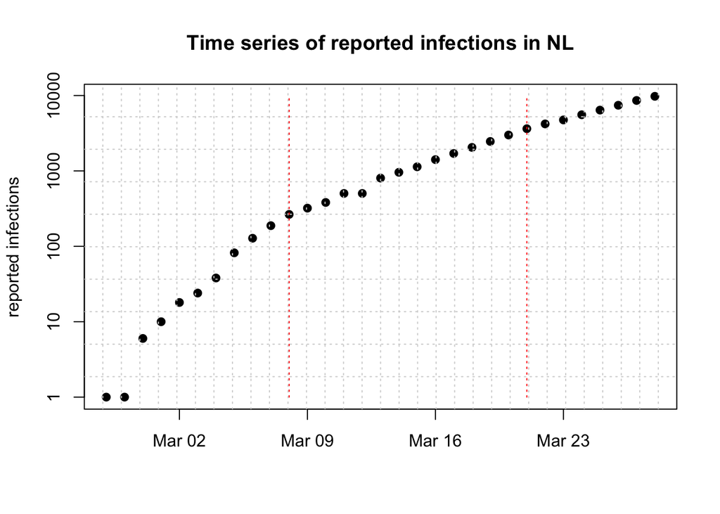

The slope of this linear relation equals $\beta - \gamma$ by virtue of relation $\eqref{Irep.t}$ above. The slope is[^5]

```
## [1] "0.20 [1/day]"
```

This result is further corroborated by the individual (day-to-day) estimates,

```
##            t    I  logratio
## 1 2020-03-14  959 0.1762918
## 2 2020-03-15 1135 0.1684969
## 3 2020-03-16 1413 0.2190825
## 4 2020-03-17 1705 0.1878500
## 5 2020-03-18 2051 0.1847624
## 6 2020-03-19 2460 0.1818339
## 7 2020-03-20 2994 0.1964489
## 8 2020-03-21 3631 0.1928978
```

having average 0.19. We use the value 0.2 for the slope, which results in the final estimates[^6]
$$\begin{equation}
\label{beta.gamma.est}
\beta \approx 0.27\ \mathrm{day}^{-1}
\quad\mbox{and}\quad
\gamma \approx 0.07 \ \mathrm{day}^{-1} .
\end{equation}$$

**Estimating $R_0$.** According to this simple model and estimates $\eqref{beta.gamma.est}$, the *basic reproduction number* $R_0$ is
$$R_0 = \beta T_\mathrm{rec} = \frac{\beta}{\gamma} = 3.9 .$$
This value is very much in the upper range of worldwide $R_0$ [estimates](https://gabgoh.github.io/COVID/index.html). It is unclear, right now, which part of the discrepancy between his estimate and the oft-quoted nominal value $R_0 = 2.2$ is actual and which is an artifact of the model or its calibration.

**Estimating $p$.** The most difficult (if not impossible) task is to estimate the correspondence (proportion) between actual infections and officially reported numbers. Since testing is limited as described above, any estimate of $p$ can only be indirect, largely arbitrary and in danger of grossly misrepresenting the actual value. If $p$ is smaller or larger than estimated, then the number of actual cases is under- or overestimated *proportionally*. This is a major limitation of the model.

To appreciate the challlenge, consider the examples of South Korea and Italy, both of which tested inhabitants extensively. The former reported $67$ deaths in approximately $8,000$ reported cases corresponding to $222,000$ administered tests. The latter, on the other hand, had (roughly) $1,000$ deaths in $15,000$ cases corresponding to $73,000$ tests ([source](https://www.reuters.com/article/us-health-coronavirus-response-specialre/special-report-italy-and-south-korea-virus-outbreaks-reveal-disparity-in-deaths-and-tactics-idUSKBN20Z27P)). These poportions are nowhere near comparable and estimates of $p$ based on one or another will vary considerably.

For NL specificaly, case fatality runs at approximately $5\%$ at the time of writing. The corresponding number is ten times lower in neighboring Germany, which [tests more extensively than any other country](https://www.ft.com/content/c0755b30-69bb-11ea-800d-da70cff6e4d3), indicating that NL might be underreporting infections by a factor of $10$. Similarly, a [recent modeling study](https://science.sciencemag.org/content/early/2020/03/13/science.abb3221) using data from the Chinese outbreak (case mortality $4\%$) estimated $p$ to be approximately $7$ and the Greek administration [estimates](https://www.kathimerini.gr/1070487/article/epikairothta/ellada/swt-tsiodras-ews-10000-atoma-exoyn-prosvlh8ei-sthn-ellada) $p$ to be *at least* $12 - 14$. As a ballpark estimate, we use the value $p = 10$ for the rest of this study, noting that errors in that value are passed on to model-projected hospitalization numbers *proportionally*.

## Methodology

Given parameter estimates, one can simulate the SIR model and compute the maximum number of (actual) infecteds achieved during the outbreak. Since one out of $p$ *actual* cases is reported by $\eqref{p.def}$ and [one out of four](https://www.volkskrant.nl/nieuws-achtergrond/meer-doden-en-iets-minder-ziekenhuisopnames-door-uitbraak-coronavirus~b9d4fb61/) *officially reported* cases ends up in the hospital, hospitalizations account for $0.25 \cdot 1/p$ of the infection numbers:
$$I_\mathrm{hosp}(t) = \frac{0.25}{p} \, I(t) ,
\quad\mbox{which reads}\
I_\mathrm{hosp}(t) = 0.025 \, I(t)
\ \mbox{for $p=10$ specifically.}$$
This simulation can be easily repeated for different parameter settings — predominantly $\beta$ and $p$ — to estimate parameter sensitivities. Containment measures, such as social distancing or quarantining, are expected to lower the value of $\beta$. We shall see that this, in turn, reduces the maximum number of infecteds — and thus also of hospitalizations — and drags out the epidemic.

The point here is to estimate:

- The range of $\beta$ for which hospitalizations remain within the health system capacity;
- The time until the epidemic reaches its apex, i.e. $I(t)$ is maximized.

NL has [roughly $38,000$ hospital beds](https://www.staatvenz.nl/kerncijfers/ziekenhuisbedden), and I take that number to be the health system capacity. This is a significantly generous assumption, as it amounts to *allocating all hospital beds to COVID-19 patients*.[^7] This assumption entails that $I_\mathrm{hosp}(t)$ must remain *below* $38,000$ at all times and all the way to the apex. For our model, the apex occurs when
$$\beta \frac{S}{N} - \gamma = 0
\quad\mbox{or, equivalently,}\quad
S = \frac{N}{R_0} .$$
Since $S$ decreases with time, it suffices to integrate the model until the moment $t^*$ where $S(t^*) = N / R_0$. That time is the period until the epidemic reaches its apex. The maximum number of infecteds is then $I(t^*)$ and of hospitalizations $0.25 \cdot 1/p \cdot I(t^*)$.

It would make sense to introduce distinct compartments for infecteds that (a) are hospitalized; (b) tested positive without being hospitalized and (c) were not tested at all, at they receive different advice and treatment and thus have different infectious potential. However, this is one of the many model improvements that are beyond the scope of this simple investigation. After all, this limitation is mitigated for $p=10$ or greater because the large majority forms a uniform group of undetected infections.

## Results

**Projected situation without intervention**

I take March 22 as beginning of the simulation.[^8] Shown below is a simulation corresponding to the epidemiological parameters in NL on March 22 and to $p=10$ (i.e. $90\%$ of infections going unreported); note the logarithmic scale on the vertical axis. The grey curve shows the evolution of (actual) active cases in time and the red one that of hospitalizations; the green line marks health system capacity. The model projection is that, within roughly a month, there will be 6.7 million active infections in NL, $168,000$ of which in need of hospitalization — a number exceeding capacity by a staggering factor of 4.4. At that point, 4.4 million individuals will be susceptible and 6 million removed from the susceptible pool.

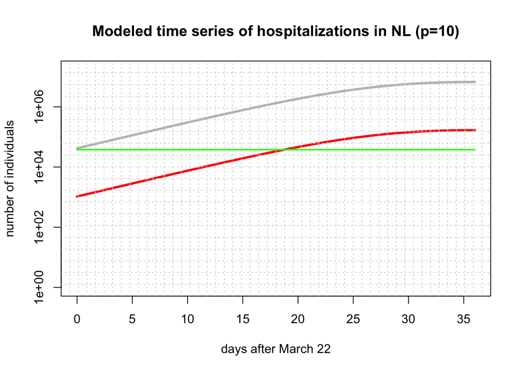

Note carefully that this is *not* the total number of hospitalizations throughout the duration of the epidemic. Also note that this is a mere prediction based on a simplistic model that assumes $90\%$ of cases going unreported. Unsurprisingly, that percentage would need to climb to $98\%$ ($p \approx 45$) for hospital beds to suffice. Although the possibility of such sparse detection rate cannot be readily refuted, there is no data supporting it either. In fact, if $p$ held that extreme value, then $1\%$ of the population would have been infected already on March 22 and over $2\%$ five days later. Had that been the case, case fatality would be in the range $0.09-0.14\%$, i.e. [in par with seasonal influenza](https://www.cdc.gov/flu/about/burden/index.html).[^9]

**Projected intervention impact**

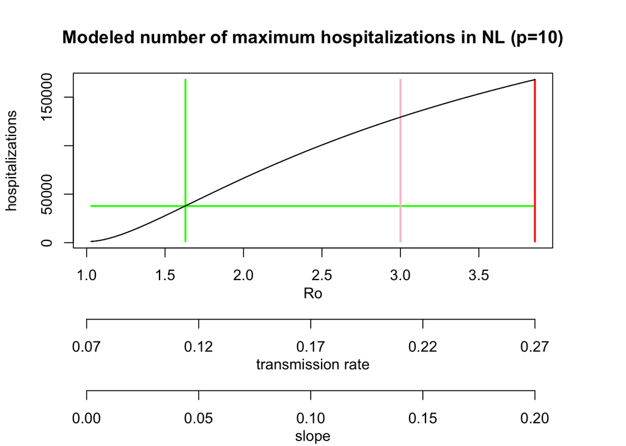

Note the *near linearity* of the plot: for beds to suffice, according to this projection, the transmission rate would need to be *more than halved* — $\beta = 0.11$ or $R_0 = 1.6$, amounting to reduction by $60\%$. The slope, on the other hand, would need to be reduced nearly by $80\%$ down to $0.045$.[^11]

A first estimate of measure efficacy is now possible, since measures took effect two weeks ago (March 16). A quantitative change in the growth rate can be seen a week later, consistent with the average incubation period.[^12] The individual (day-to-day) estimates for the slope are shown below

```
##            t    I  logratio
## 1 2020-03-22 4204 0.1465284
## 2 2020-03-23 4749 0.1218976
## 3 2020-03-24 5560 0.1576640
## 4 2020-03-25 6412 0.1425731
## 5 2020-03-26 7431 0.1474892
## 6 2020-03-27 8603 0.1464505
## 7 2020-03-28 9762 0.1263863
```

Their average is 0.14, a $30\%$ decrease from the period leading up to March 22, and consistent with the linear fit to the data that yields slope

```
## [1] "0.14 [1/day]"
```

This marks a concurrent $22\%$ decrease in the epidemiological parameters, bringing them down to $\beta = 0.21$ and $R_0 = 3$. The expected maximum number of hospitalizations is $130,000$ in this scenario, with the peak occuring roughly seven weeks after March 22. This is still 3.3 times the capacity, pointing to a clear need for additional measures.

## Conclusion

I undertook this short study to shed some (arguably diffuse) light on how the herd immunity story will play out in NL in the full or partial absence of transmission-mitigating measures. At the same time, I attempted to estimate measure efficacy guaranteeing proper hospitalization for all in need. The study was undertaken with full knowledge of data gaps amd model limitations and its findings should be interpreted as mere rough projections.

The main finding is the need for social distancing measures to slow down the epidemic. In the absence of such measures, the Dutch health system would have been (vastly) overwhelmed within a couple of weeks and the majority of those needing hospitalization would be denied it. The data show a clear slow-down in the last week that is consistent with measures introduced by the government. However, model projections show the need for substantial additional slow-down to avoid the scenario above. According to the same projections, the measures taken pushed off the peak from late April to mid-May. Strengthening the measures to the point where herd immunity can set on without ovewhelming the health system would delay this further until mid-summer. Since litle is known about weather influence, however, this particular projection is of little predictive value.

[^1]: The more people are immune the fewer can get infected, so disease spead slows down and outbreaks die out. This is the same principle underlying mass vaccination programs, with the important distinction that vaccines are much safer than the disease itself. At this time, a vaccine against COVID-19 is nowhere within sight.
[^2]: In my experience, a data-calibrated simplistic model is preferable to a realistic model where parameters must be guessed.
[^3]: Non-hospitalized persons are [only tested](https://lci.rivm.nl/nieuws/casusdefinitie-en-testbeleid-covid-19-aangepast) if they are high-risk and already exhibit acute symptoms (fever and either cough or dyspnea).
[^4]: The outlier on March 12 likely points to lack of reporting on that day.
[^5]: The outlying measurement of March 12 affects the slope merely by $1\%$.
[^6]: The estimates above of a 22$\%$ daily and 300$\%$ weekly increase of infection numbers (both reported and actual) are based on these values for $\beta$ and $\gamma$ through $\mathrm{e}^{\beta - \gamma} \approx 1.22$ and $\mathrm{e}^{7(\beta - \gamma)} \approx 4$.
[^7]: In reality, [only $38\%$ of those beds are readily available](https://www.volkskrant.nl/nieuws-achtergrond/hoe-snel-zijn-de-bedden-in-het-ziekenhuis-op-door-uitbraak-van-het-coronavirus~bfe053d4/).
[^8]: For simplicity, I simulate the SIR model using RK4 with $dt = 0.1 \ \mathrm{day}$ guaranteeing sufficient accuracy.
[^9]: This argument was [made earlier](https://www.statnews.com/2020/03/17/a-fiasco-in-the-making-as-the-coronavirus-pandemic-takes-hold-we-are-making-decisions-without-reliable-data/) by J. Ioannidis.
[^10]: These quantities are linearly related: $R_0 = \beta/\gamma$ and $\mathrm{slope} = \beta - \gamma$, with $\gamma = 0.07$ fixed.
[^11]: The reason for this discrepancy is that $\beta$ and $R_0$ are directly proportional, whereas the slope factors in an offset.
[^12]: See also [this](https://medium.com/@tomaspueyo/coronavirus-act-today-or-people-will-die-f4d3d9cd99ca) on the subject.